# Data 607 Project 2

John Perez

3/3/2019

# Data set 1 - WW2 planes

## Introduction

This dataset includes information about the cost of the military planes used during World War 2. The filetype is a csv with tab seperated values. In order to properly interpret the tabs, we simply indicate the seperator as being “\t”.  
First we will import the file, then “tidy” it into a usable form for later analysis.

```r
file<- "RawCost.csv"
rawdf<-read.csv(file, sep="\t",header=TRUE,fill=TRUE)
head(rawdf,5)
```

```
##                  Type Model    X1941    X1942 X1943    X1944   X1945
## 1 Very Heavy Bombers
## 2                     B-29           897,730        605,360  509,465
## 3      Heavy Bombers
## 4                     B-17  301,221  258,949        204,370  187,742
## 5                     B-24  379,162  304,391        215,516        -
```

As we see above, we make the following observations on the data:

- The data is “wide”, containing columns that are a variable (year).
- There are many missing fields.
- The numerical columns contain commas and have been interpreted as character factors.
- Many cells contain extraneous whitespace

We will correct each of these items.

### Tidy operations

We begin tidying the data by adding interpretable NAs (to be used later to fill in the missing values) to the “Type” column and remove the rows that do not have a value for the column “Model”.

```r
empty_as_na <- function(x){
    if("factor" %in% class(x)) x <- as.character(x) ## since ifelse wont work with factors
    ifelse(as.character(x)!="", x, NA)
}
df <- rawdf
df$Type <- empty_as_na(df$Type)
df$Model[df$Model == "  "] <- NA

head(df,5)
```

```
##                  Type Model    X1941    X1942 X1943    X1944   X1945
## 1 Very Heavy Bombers   <NA>
## 2                <NA> B-29           897,730        605,360  509,465
## 3      Heavy Bombers   <NA>
## 4                <NA> B-17  301,221  258,949        204,370  187,742
## 5                <NA> B-24  379,162  304,391        215,516        -
```

In order to populate the “Type” column’s missing values, we will fill in the NA values created in the prior step in the “Type” column with the previous value encountered in the same column using a solution from the R Graphics Cookbook by Winston Chang.<sup>1</sup>

```r
fillNAgaps <- function(x, firstBack=FALSE) {
    lvls <- NULL
    if (is.factor(x)) {
        lvls <- levels(x)
        x    <- as.integer(x)
    }
    goodIdx <- !is.na(x)
    if (firstBack)   goodVals <- c(x[goodIdx][1], x[goodIdx])
    else             goodVals <- c(NA,            x[goodIdx])
    fillIdx <- cumsum(goodIdx)+1
    x <- goodVals[fillIdx]
    if (!is.null(lvls)) {
        x <- factor(x, levels=seq_along(lvls), labels=lvls)
    }
    x
}
df$Type <- fillNAgaps(df$Type)
df<- df[!is.na(df$Model),]
head(df,5)
```

```
##                  Type Model    X1941    X1942    X1943    X1944   X1945
## 2 Very Heavy Bombers  B-29           897,730           605,360  509,465
## 4      Heavy Bombers  B-17  301,221  258,949           204,370  187,742
## 5      Heavy Bombers  B-24  379,162  304,391           215,516        -
## 6      Heavy Bombers  B-32        -  790,433        -  790,433        -
## 8     Medium Bombers  B-25  180,031  153,396  151,894  142,194  116,752
```

As shown above, we now have a value in the Type column for each row corresponding to each aircraft model.  
The dataframe is still wide though, having columns representing years. We will gather these into one “Year” column and a corresponding value “Cost” column in the chunk below.  
Additionally, we will convert dashes and empty cells into NA.  
At the end of this step, we will have a tidy dataframe which we can use to look at the average cost of each aircraft type.

```r
colnames(df)[3:7] <- c("1941","1942","1943","1944","1945")
df <- gather(df, "Year", "Cost", 3:7)
df$Year <- as.integer(df$Year)
df$Cost <- str_trim(sub(",", "", df$Cost, fixed = TRUE))
df$Cost[df$Cost == "-" | df$Cost == ""] <- NA
df$Cost <- as.integer(df$Cost)
df$Model <- str_trim(df$Model)
head(df,5)
```

```
##                  Type Model Year   Cost
## 1 Very Heavy Bombers   B-29 1941     NA
## 2      Heavy Bombers   B-17 1941 301221
## 3      Heavy Bombers   B-24 1941 379162
## 4      Heavy Bombers   B-32 1941     NA
## 5     Medium Bombers   B-25 1941 180031
```

## Exploration

Now that we have tidied the data, we can perform some exploratory analysis on it such as looking at the average cost of each aircraft type over the course of the war. We will present that in a horizontal bar plot.

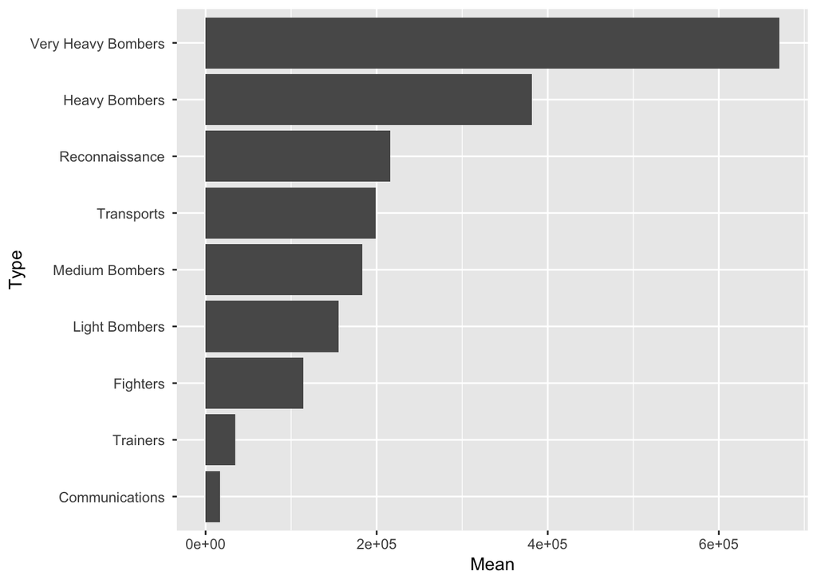

```r
means<- df %>% group_by(Type) %>% summarize(Mean=round(mean(Cost,na.rm=TRUE),0))
ggplot(means, aes(x=reorder(Type, Mean), y= Mean)) +
    xlab("Type") +
    geom_col() +
    coord_flip()
```

# Data set 2 - Hospital Complications and Deaths

## Introduction

The next dataset we will manipulate concerns hospital complications and deaths. One possible insight we’d like to gain from this dataset is assessing the top 10 best and worst hospitals in the country. We will perform the necessary operations to rank and populate the 10 best and worst into a table.  
First we load the data into a dataframe…

```r
file <-"Complications_and_Deaths_-_Hospital.csv"
df2 <-read.csv(file,header=TRUE,fill=TRUE,stringsAsFactors=FALSE)
datatable(head(df2,5),options=list(pageLength=5,autoHideNavigation=TRUE))
```

|  | Provider.ID | Hospital.Name | Address | City | State | ZIP.Code | County.Name | Phone.Number | Measure.Name | Measure.ID | Compared.to.National | Denominator | Score | Lower.Estimate | Higher.Estimate | Footnote | Measure.Start.Date | Measure.End.Date | Location |
| --- | --- | --- | --- | --- | --- | --- | --- | --- | --- | --- | --- | --- | --- | --- | --- | --- | --- | --- | --- |
| 1 | 271344 | SIDNEY HEALTH CENTER | 216 14TH AVE SW | SIDNEY | MT | 59270 | RICHLAND | 4064882100 | Death rate for pneumonia patients | MORT_30_PN | No Different than the National Rate | 89 | 13.9 | 10.2 | 18.6 |  | 07/01/2014 | 06/30/2017 | 216 14TH AVE SW SIDNEY, MT 59270 (47.715839, -104.174171) |
| 2 | 281311 | FRANKLIN COUNTY MEMORIAL HOSPITAL | 1406 Q ST | FRANKLIN | NE | 68939 | FRANKLIN | 3084256221 | A wound that splits open after surgery on the abdomen or pelvis | PSI_14_POSTOP_DEHIS | Not Available | Not Available | Not Available | Not Available | Not Available | 13 - Results cannot be calculated for this reporting period. |  |  | 1406 Q ST FRANKLIN, NE 68939 (40.101552, -98.954353) |
| 3 | 280105 | CHI HEALTH MIDLANDS | 11111 SOUTH 84TH ST | PAPILLION | NE | 68046 | SARPY | 4025933000 | Accidental cuts and tears from medical treatment | PSI_15_ACC_LAC | No Different than the National Rate | 166 | 1.24 | 0.14 | 2.34 |  |  |  | 11111 SOUTH 84TH ST PAPILLION, NE 68046 (41.136866, -96.042825) |
| 4 | 281304 | THAYER COUNTY HEALTH SERVICES | 120 PARK AVE | HEBRON | NE | 68370 | THAYER | 4027686041 | Postoperative Acute Kidney Injury Requiring Dialysis Rate | PSI_10_POST_KIDNEY | Not Available | Not Available | Not Available | Not Available | Not Available | 13 - Results cannot be calculated for this reporting period. |  |  | 120 PARK AVE HEBRON, NE 68370 (40.160123, -97.593267) |
| 5 | 271342 | DANIELS MEMORIAL HOSPITAL | 105 5TH AVE E | SCOBEY | MT | 59263 | DANIELS | 4064872296 | Collapsed lung due to medical treatment | PSI_6_IAT_PTX | Not Available | Not Available | Not Available | Not Available | Not Available | 13 - Results cannot be calculated for this reporting period. |  |  | 105 5TH AVE E SCOBEY, MT 59263 (48.788624, -105.418587) |

As we see there are many columns and rows (example above limited to 5 for space).

We are interested in finding out the most problematic Adverse Events for underperforming hospitals, as well as how hospitals perform in comparison to the national average and ranking the best and worst in terms of that variable.

Below we perform the following adjustments to the dataframe:

- Remove rows which do not have a score for a given measure
- Convert the Compared.to.National and Measure.Name columns into factors
- Replace the string levels in Compared.to.National with numbers -1,0,1 (corresponding to worse, average, better than average respectively) so we can later perform summary operations on them

For reference, below we print the existing string levels and and show how the transformation changes these to numeric values.

```r
df2 <- df2[df2$Score!="Not Available",]
df2$Compared.to.National <- as.factor(df2$Compared.to.National)
df2$Measure.Name <- as.factor(df2$Measure.Name)
levels(df2$Compared.to.National)
```

```
## [1] "Better than the National Rate"
## [2] "Better than the National Value"
## [3] "No Different than the National Rate"
## [4] "No Different than the National Value"
## [5] "Worse than the National Rate"
## [6] "Worse than the National Value"
```

```r
levels(df2$Compared.to.National) <- c(1,1,0,0,-1,-1)
levels(df2$Compared.to.National)
```

```
## [1] "1"  "0"  "-1"
```

To ensure the transformation was done properly, here are 2 rows for each of the Compared.To.National levels:

```r
ex1<-head(df2[df2$Compared.to.National==1,c("Provider.ID","Measure.Name","Compared.to.National")],2)
ex2<-head(df2[df2$Compared.to.National==0,c("Provider.ID","Measure.Name","Compared.to.National")],2)
ex3<-head(df2[df2$Compared.to.National==-1,c("Provider.ID","Measure.Name","Compared.to.National")],2)
rbind(ex1,ex2,ex3)
```

```
##      Provider.ID                                     Measure.Name
## 1198      520098             Blood stream infection after surgery
## 1346      290009                                   Pressure sores
## 1         271344                Death rate for pneumonia patients
## 3         280105 Accidental cuts and tears from medical treatment
## 22        010005                     Death rate for COPD patients
## 23        010005            Death rate for heart failure patients
##      Compared.to.National
## 1198                    1
## 1346                    1
## 1                       0
## 3                       0
## 22                     -1
## 23                     -1
```

Now that the levels are normalized lets answer our initial questions…

### Which measures of Adverse Events are the most problematic for physicians?

Below we isolate the instances where a provider performs a given measure worse than national average, count the occurences, then generate a bar plot.  
This shows that the top five measures being performed worse than average are:

1. Death rate for pneumonia patients
2. Pressure sores
3. Serious complications
4. Postoperative Respiratory Failure Rate
5. Death rate for heart failure patients

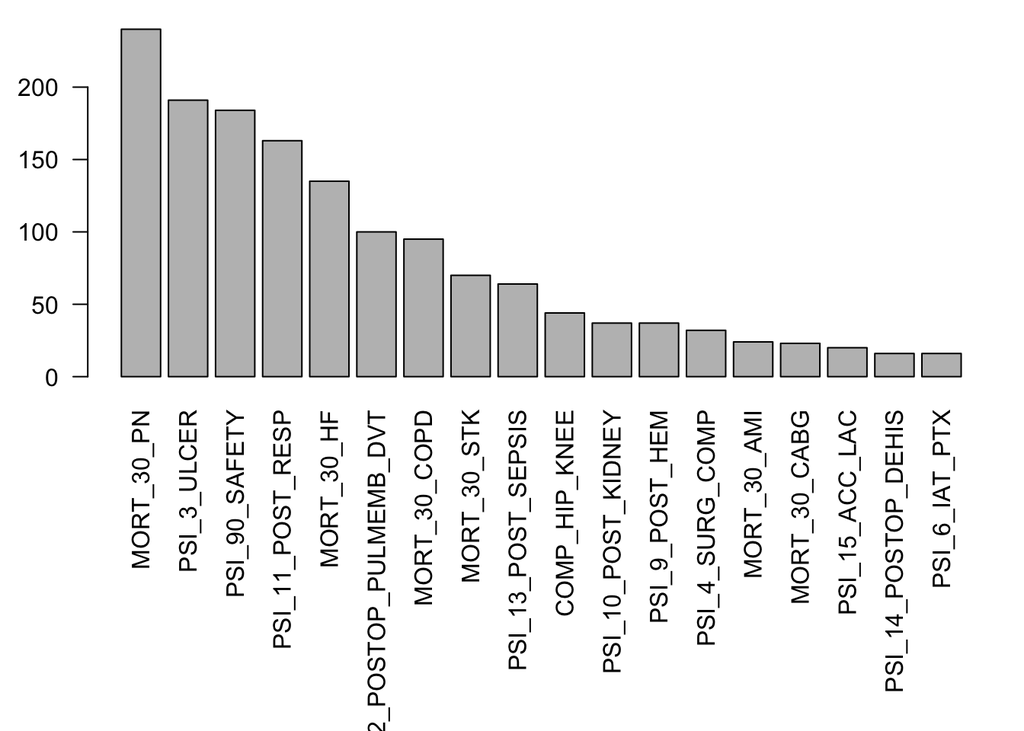

```r
worst<- df2[df2$Compared.to.National==-1,]
par(mar=c(12,3,1,1))
barplot(sort(table(worst$Measure.ID),decreasing=TRUE), las=2)
```

### Which are the 10 best Hospitals?

Below we look for the 10 hospitals that have the most number of measures being performed better than the national average by their physicians. In order to rank them, we’ll group the dataframe by **Hospital.Name** then sum the **Compared.to.National** values for each. Since we previously converted that column into numeric values [-1,0,1] we can sum them to see how many *more* measures they are performing better than average in.

```r
df2$Compared.to.National <- as.numeric(levels(df2$Compared.to.National))[df2$Compared.to.National]
Hospitals <- df2 %>% group_by(Hospital.Name) %>% summarize(sum=sum(Compared.to.National))
bestHospitals <- subset(Hospitals, sum>0)
tenBest <- bestHospitals[order(bestHospitals$sum, decreasing=TRUE),][1:10,]
datatable(tenBest)
```

|  | Hospital.Name | sum |
| --- | --- | --- |
| 1 | CLEVELAND CLINIC | 8 |
| 2 | BRIGHAM AND WOMEN'S HOSPITAL | 6 |
| 3 | CEDARS-SINAI MEDICAL CENTER | 6 |
| 4 | CENTINELA HOSPITAL MEDICAL CENTER | 6 |
| 5 | FLORIDA HOSPITAL | 6 |
| 6 | MAYO CLINIC HOSPITAL | 6 |
| 7 | UNIVERSITY OF MICHIGAN HEALTH SYSTEM | 6 |
| 8 | BEAUMONT HOSPITAL, ROYAL OAK | 5 |
| 9 | BEAUMONT HOSPITAL, TROY | 5 |
| 10 | HILLCREST HOSPITAL | 5 |

### Which are the 10 worst Hospitals?

Here we’ll perform the same analysis but inverted to find the worst hospitals.

```r
worstHospitals <- subset(Hospitals, sum<0)
tenWorst <- worstHospitals[order(worstHospitals$sum),][1:10,]
datatable(tenWorst)
```

|  | Hospital.Name | sum |
| --- | --- | --- |
| 1 | UNIVERSITY OF MISSISSIPPI MED CENTER | -10 |
| 2 | FORREST GENERAL HOSPITAL | -7 |
| 3 | JACKSON MEMORIAL HOSPITAL | -7 |
| 4 | TAMPA GENERAL HOSPITAL | -7 |
| 5 | UNIVERSITY MEDICAL CENTER | -7 |
| 6 | MEMORIAL MEDICAL CENTER | -6 |
| 7 | O U MEDICINE | -6 |
| 8 | THOMAS JEFFERSON UNIVERSITY HOSPITAL | -6 |
| 9 | BAPTIST HEALTH LOUISVILLE | -5 |
| 10 | BAPTIST HEALTH MEDICAL CENTER-LITTLE ROCK | -5 |

# Dataset 3 - Google Play Store apps

## Introduction

Here we will be working with a dataset containing all the Google Play Store apps and various variables related to each. Some possible analyses we can perform on this dataset includes finding out which are the top apps by installs. We can also look at the different categories of apps, the number of free and paid apps, and how ratings compare between free and paid.

### Load Data Into Dataframe

Below we load the data and remove some duplicate rows.

```r
apps <- read.csv("googleplaystore.csv")
apps <- apps[!duplicated(apps$App),] #remove duplicates
head(apps,5)
```

```
##                                                  App       Category Rating
## 1     Photo Editor & Candy Camera & Grid & ScrapBook ART_AND_DESIGN    4.1
## 2                                Coloring book moana ART_AND_DESIGN    3.9
## 3 U Launcher Lite – FREE Live Cool Themes, Hide Apps ART_AND_DESIGN    4.7
## 4                              Sketch - Draw & Paint ART_AND_DESIGN    4.5
## 5              Pixel Draw - Number Art Coloring Book ART_AND_DESIGN    4.3
##   Reviews Size    Installs Type Price Content.Rating
## 1     159  19M     10,000+ Free     0       Everyone
## 2     967  14M    500,000+ Free     0       Everyone
## 3   87510 8.7M  5,000,000+ Free     0       Everyone
## 4  215644  25M 50,000,000+ Free     0           Teen
## 5     967 2.8M    100,000+ Free     0       Everyone
##                      Genres     Last.Updated        Current.Ver
## 1              Art & Design  January 7, 2018              1.0.0
## 2 Art & Design;Pretend Play January 15, 2018              2.0.0
## 3              Art & Design   August 1, 2018              1.2.4
## 4              Art & Design     June 8, 2018 Varies with device
## 5   Art & Design;Creativity    June 20, 2018                1.1
##    Android.Ver
## 1 4.0.3 and up
## 2 4.0.3 and up
## 3 4.0.3 and up
## 4   4.2 and up
## 5   4.4 and up
```

First we’d like to see which are the most installed apps. One issue with the dataset as we can see above, is that the **Installs** column is composed of text strings. Below, we will transform those values into integers using the gsub() function. Afterward we’ll be able to sort the dataframe by the **Installs** column.

```r
apps$Installs <- suppressWarnings(as.numeric(gsub(",", "", str_extract_all(apps$Installs, ".+?(?=\\+)"))))
app_installs <- apps %>% group_by(App) %>% summarize(Installs=Installs) %>% arrange(desc(Installs))
datatable(app_installs)
```

|  | App | Installs |
| --- | --- | --- |
| 1 | Facebook | 1000000000 |
| 2 | Gmail | 1000000000 |
| 3 | Google | 1000000000 |
| 4 | Google Chrome: Fast &amp; Secure | 1000000000 |
| 5 | Google Drive | 1000000000 |
| 6 | Google News | 1000000000 |
| 7 | Google Photos | 1000000000 |
| 8 | Google Play Books | 1000000000 |
| 9 | Google Play Games | 1000000000 |
| 10 | Google Play Movies &amp; TV | 1000000000 |

[output cut: 9650 more lines]

### Distribution of Apps by Category & Type

Next let’s look at the different categories of apps and whether they are free or paid.

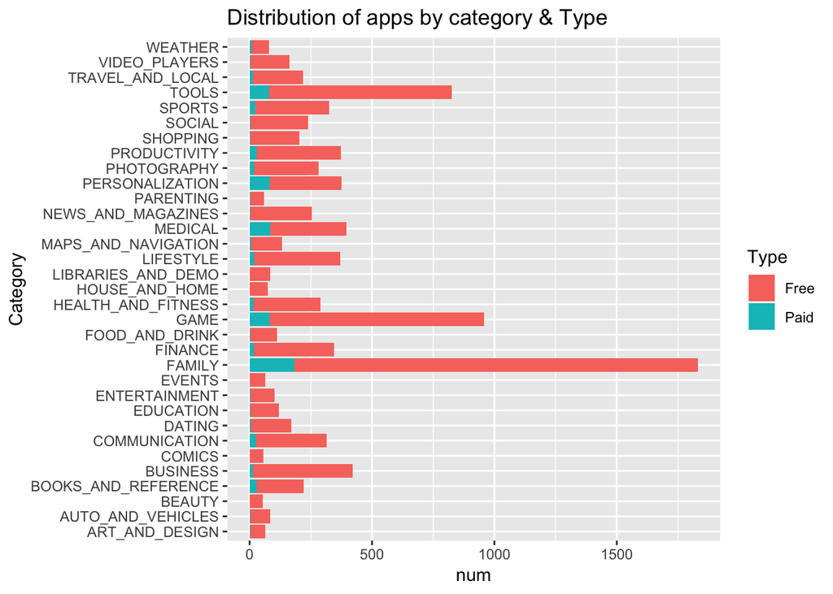

```r
categoryDistr <- apps[-10473,]
categoryDistr <- categoryDistr[categoryDistr$Type=="Free" | categoryDistr$Type=="Paid",]
categoryDistr <- categoryDistr %>%
  group_by(Category, Type) %>%
  summarise(num = length(Category))

ggplot(categoryDistr, aes(x=Category, y=num, fill=Type)) +
    xlab("Category") +
    geom_bar(stat="identity") +
    coord_flip() +
    ggtitle("Distribution of apps by category & Type")
```

Finally let’s take a look at the distribution of ratings for both free and paid apps. Once again, the **Price** column is interpreted as characters with a dollar sign. In order to perform this analysis we’ll have to convert this into an interpretable number. This will be accomplished by using a regex isolate just the numbers, then cast that into numeric class.

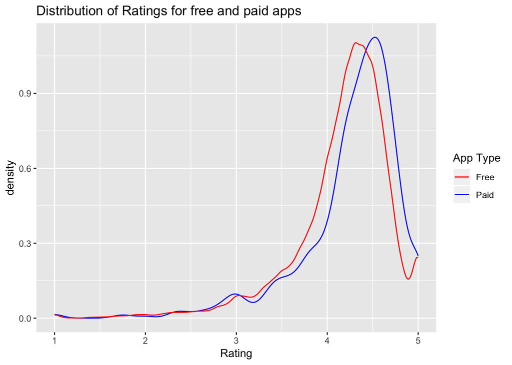

```r
apps$Price <- as.character(apps$Price)
apps$Price <- as.numeric(str_extract_all(apps$Price, "\\d+(\\.\\d+)?"))

freeRatings <- apps[apps$Price==0,]
paidRatings <- apps[apps$Price!=0,]
par(mfrow=c(1,2))
ggplot(paidRatings, aes(x=Rating)) +
    geom_line(stat="density", aes(color="Paid")) +
    geom_line(data=freeRatings, stat="density", aes(color="Free")) +
    ggtitle("Distribution of Ratings for free and paid apps") +
    scale_color_manual(values = c(
    "Paid" = "blue",
    "Free" = "red")) +
    labs(color = "App Type")
```

```r
    theme(plot.title = element_text(hjust = 0.5))
```

[output not shown]

Above we can see that the vast majority of apps are free, the top 3 categories are *Family, Games,* and *tools*. We can also see that paid apps tend to be rated higher than free apps.

Sources:  
https://stackoverflow.com/questions/24172111/change-the-blank-cells-to-na  
http://www.cookbook-r.com/Manipulating_data/Filling_in_NAs_with_last_non-NA_value/